# Pre-Covid U.S. Airline Traffic Analysis

# Introduction

The airline industry plays an integral role in how the U.S. functions. It not only contributes to the continued growth of the economy, but also facilitates a level of global connectivity which seemed impossible a century ago (1). The data collected on the number of flights over time offers a valuable opportunity to learn the evolving travel patterns of the country’s citizens. Moreover, it allows for a deeper understanding of the impact of seasonality, economic progress, etc. on air travel. By analyzing how the volume of flights changes throughout the year and across years, interested parties such as stakeholders can better anticipate future demand and optimize the air travel process (2).

The motivation of this time series data analysis project is to contribute to the growing pool of research determined to uncover the underlying patterns within airline traffic data and offer insight into appropriate models. The data set used for this analysis was downloaded from Kaggle and contains monthly U.S. airline traffic data between January 2003 and December 2019 (3). Specifically, for each month in this time period, there is a recorded value for the total number of flights originating in the U.S. from all commercial U.S. air carriers. By analyzing the data, we aim to explore trends, seasonality, and any other interesting patterns in the airline industry, while assessing how well various models explain the data.

# Exploratory Data Analysis (EDA)

Before beginning a detailed exploratory data analysis, the first step taken was to determine if there were any NA data points for any of the recorded months.

```
## Number of NA values in the time series: 0
```

After further investigation, there were no NA values within the time series data. Therefore, there was no need to perform any data imputation methods and EDA can continue unhindered by gaps in the data.

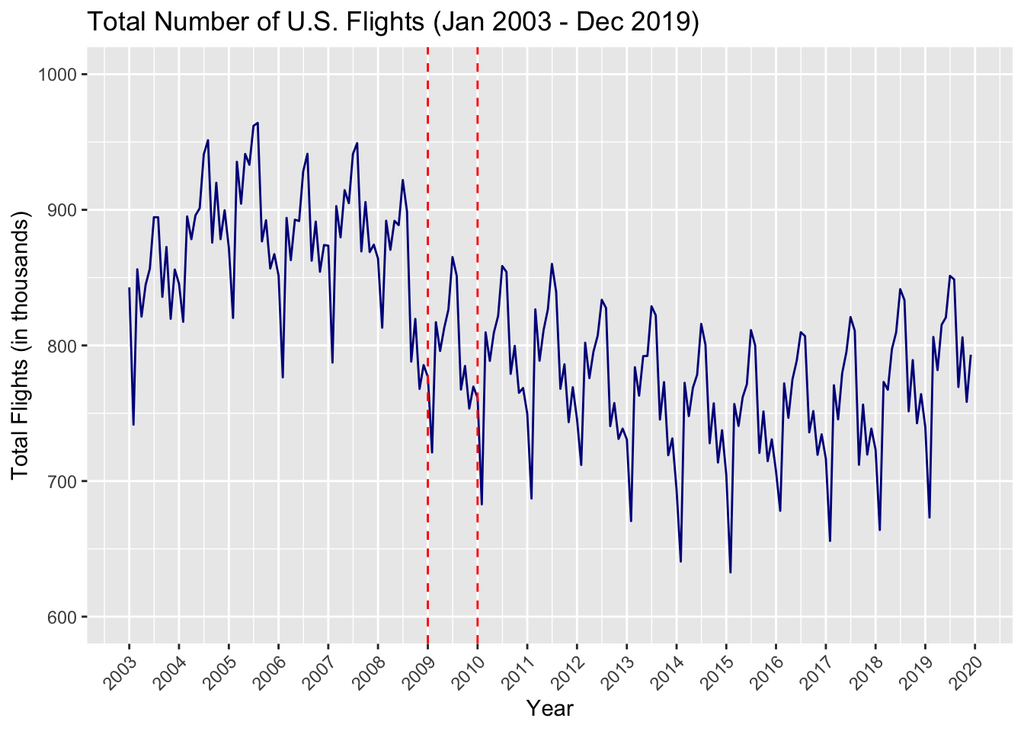

```r
data %>%
  ggplot(aes(x = month_year, y = Flt)) +
  geom_line(color = 'darkblue') +
  geom_vline(xintercept = as.Date(c("2009-01-01", "2010-01-01")), linetype = "dashed", color = "red") +
  labs(title = "Total Number of U.S. Flights (Jan 2003 - Dec 2019)", x = "Year", y = "Total Flights (in thousands)") +
  scale_x_date(
    breaks = seq(as.Date("2003-01-01"), as.Date("2024-09-01"), by = "1 year"),
    labels = scales::date_format("%Y")
  ) +
  ylim(600,1000)+
  theme(axis.text.x = element_text(angle = 45, hjust = 1),
        plot.caption.position = "plot",
        plot.caption = element_text(hjust = 0))
```

In the figure above, we see a line plot that visualizes the total number of commercial flights which originated in the U.S. (in thousands) from January 2003 to December 2019. This figure depicts potential seasonality, seen by similar patterns of increases and decreases across different years. More formally, the visual motif contained within the dashed red lines above is repeated quite similarly in other years.

Unsurprisingly, due to the similar motif across the years, the average number of flights by month maintains the same general structure.

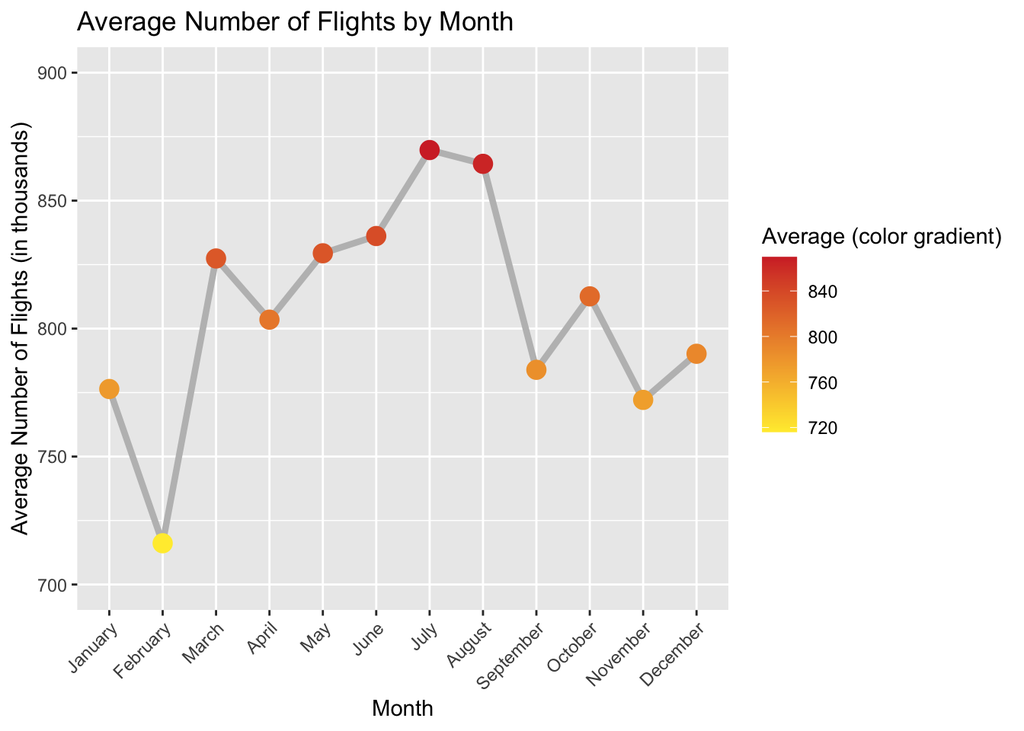

```r
# Calculate the monthly mean
data_summary <- data %>%
  mutate(month = month(Month),
         month_name = factor(month.name[month], levels = month.name)) %>%
  group_by(month_name) %>%
  summarise(Mean = round(mean(Flt, na.rm = TRUE), 2))



ggplot(data_summary, aes(x = month_name, y = Mean, group = 1)) +
  geom_line(linewidth= 1.5, color = "gray") +
  geom_point(aes(color = Mean), size = 4) +
  scale_color_gradient(low = "#FFEB3B", high = "#D32F2F") +
  labs(title = "Average Number of Flights by Month",
       x = "Month",
       y = "Average Number of Flights (in thousands)",
       color = "Average (color gradient)") +
  ylim(700, 900)+
  theme(axis.text.x = element_text(angle = 45, hjust = 1),
        plot.caption.position = "plot",
        plot.caption = element_text(hjust = 0))
```

The above figure depicts a line plot of the average number of flights by month, enhanced by a color gradient to emphasize the magnitude of the values relative to each other. When considering the context of the demand for travel based on weather conditions, these increases and decreases make sense. In the beginning of the year when it is cold (i.e. January and February), the average number of flights is low compared to the middle of the year. In the middle of the year (March to August), there is an overall increase in the average number of flights, likely due to the warmer weather and increased free time during periods like spring break and summer vacation. After this increase, there is a rebound back to lower averages when the weather once again grows cold. There is also a slight increase in December which is potentially due to an increased desire to travel near holidays like Christmas and New Years. So, it appears that the data adheres to the general connection made between the weather and the desire to travel (4).

After seeing how the average number of flights varies based on the month, it was also helpful to view the overall distribution of the number of flights.

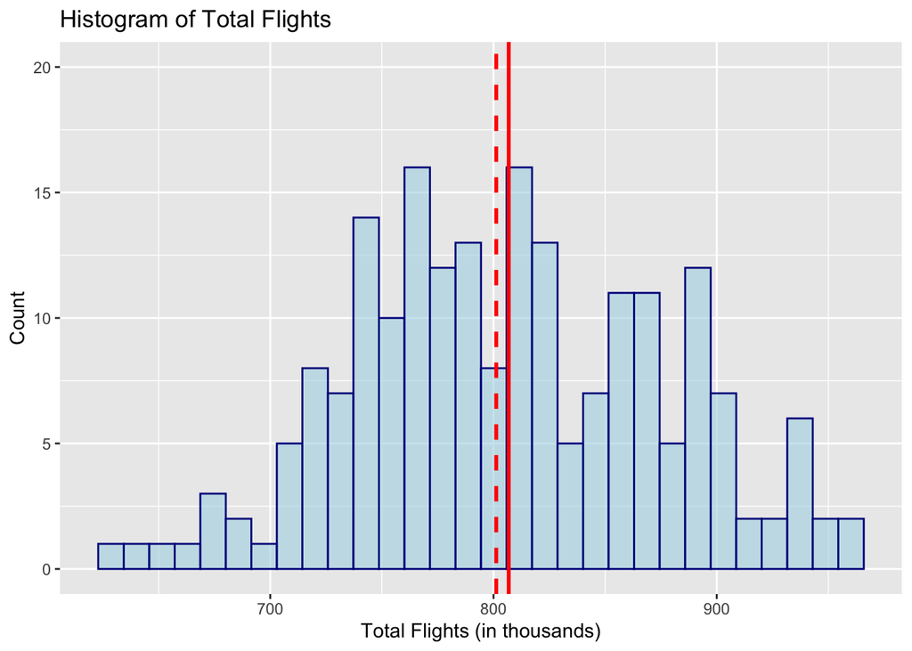

```
## Median Number of Flights (in thousands): 801.2385
```

```
## Mean Number of Flights (in thousands): 806.8299
```

```r
# Plot the distribution
data %>%
  ggplot(aes(x = Flt)) +
  geom_histogram(bins = 30, fill = "lightblue", color = "darkblue", alpha = 0.6) +
  geom_vline(aes(xintercept = mean(Flt)), color = "red", linewidth = 1) +  # Mean line
  geom_vline(aes(xintercept = median(Flt)), color = "red", linetype = "dashed", linewidth = 1) +
  labs(title = "Histogram of Total Flights",
       x = "Total Flights (in thousands)",
       y = "Count") +
  ylim(0, 20) +
  theme(plot.caption.position = "plot",
        plot.caption = element_text(hjust = 0))
```

We see the distribution of the total number of flights for all the months of recorded data between January 2003 and December 2019. The dashed red line indicates the median and the solid red line the mean of the total number of flights. As the mean is larger than the median by approximately six thousand flights, there is a slight right skew (positive skew) in the data. However, since these are pretty close together considering the magnitude of the values, this should mean that the use of some data transformation (for example, a log transformation) is not entirely necessary. In the hopes of keeping our data as interpretable as possible by avoiding the need to discuss these values on the log scale, we chose to the keep the data as is.

Now, we plan to explore how the mean of the number of flights changes over the course of our data using a rolling mean.

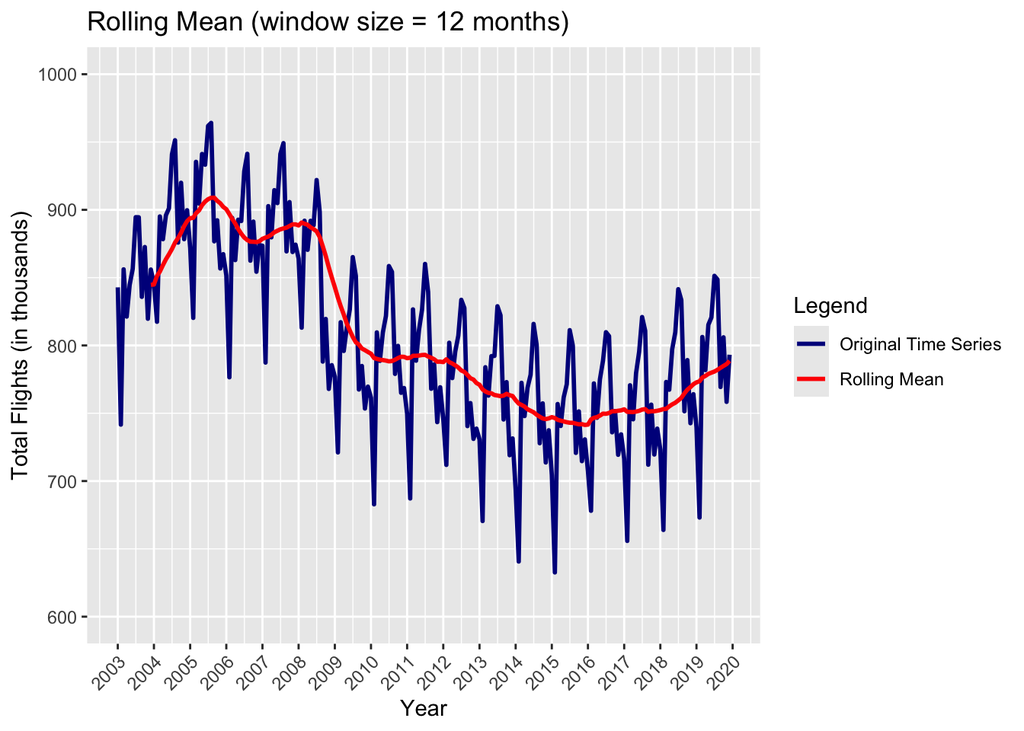

```r
# rolling mean

# create time series
time_series <- ts(data$Flt, frequency = 12)

window_size <- 12  # rolling over 12 months

# Calculate rolling mean
rolling_mean <- rollmean(time_series, window_size, fill=NA, align = "right")

df <- data.frame(
  time = data$month_year,
  actual = as.numeric(time_series),
  rolling_mean = as.numeric(rolling_mean)
)

data_long <- reshape2::melt(df, id.vars = "time",
                            measure.vars = c("actual", "rolling_mean"),
                            variable.name = "type", value.name = "value")


ggplot(data_long, aes(x = time, y = value, color = type)) +
  geom_line(linewidth = 1, na.rm = TRUE) +
  scale_color_manual(values = c("darkblue", "red"),
                     labels = c("Original Time Series", "Rolling Mean")) +
  labs(title = "Rolling Mean (window size = 12 months)",
       x = "Year",
       y = "Total Flights (in thousands)",
       color = "Legend") +
  scale_x_date(
    breaks = seq(as.Date("2003-01-01"), as.Date("2021-01-01"), by = "1 years"),
    labels = date_format("%Y")
  ) +
  ylim(600, 1000)+
  theme(axis.text.x = element_text(angle = 45, hjust = 1),plot.caption.position = "plot",
        plot.caption = element_text(hjust = 0))
```

This plot shows the rolling mean (a.k.a the moving average) of the total number of flights using a window size of 12 months. In blue, we see the original time series data and, in red, we see the the calculated rolling mean. The rolling mean with a fixed window size of 12 months calculates the average total number of flights in the last 12 months. For this reason, there are no values for the rolling mean until we see data for at least 12 months, so the red line starts at 2004 and slides over the data until the end of the time series. This process helps smooth out short-term fluctuations in the data and reveals longer-term trends. In the time period between 2004 and 2008, there is an overall increasing rolling mean which may indicate an upward trend. However, after 2008, the rolling mean appears to show a downward trend until 2016. This suggests that there were lower-than-usual total flights in this period. Some possible reasons for this are the global financial crises in 2007-2008 which reduced the demand for air travel due to economic hardships and rising fuel prices in 2008-2014 which forced airlines to raise fares or reduce flight frequencies (5)(6). Though, after 2016, there seems to have been a slight rebound upward which is possibly due to the economy stabilizing after the events of the previous period. This a useful plot because it raises the question on if the visual “trend” is actually a trend or just a trick of the eye. Later work in this analysis will attempt to determine which case is more aligned with reality.

Now, we turn our attention towards determining if there is a solid reason to believe that there exists seasonality within the data in order to inform the direction of our later analysis.

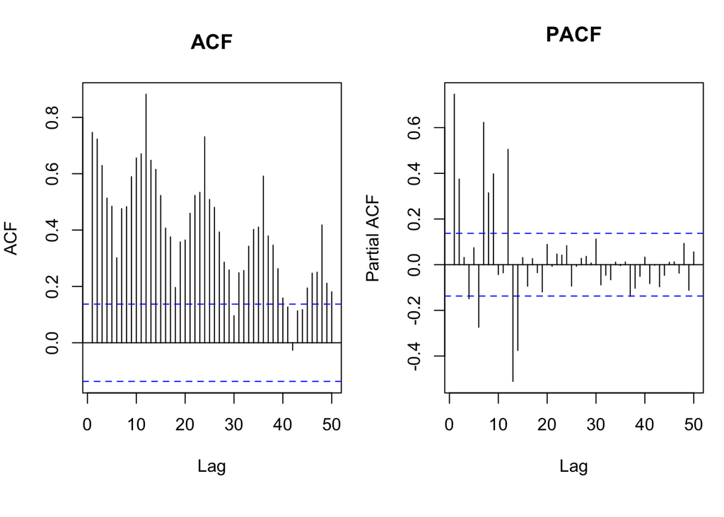

```r
ts_data <- ts(data$Flt)
par(mfrow=c(1, 2),  mar=c(6, 4, 4, 1))
acf(ts_data, main="ACF", lag.max=50)
pacf(ts_data, main="PACF", lag.max=50)
```

Above, we show both the ACF and PACF of the time series.

First, consider the ACF. The Autocorrelation Function (ACF) plot is used to investigate the correlation of a time series with its own past values (lags) in order to identify patterns or dependencies over time (7). In this figure, we see a slow decay which may indicate the presence of a trend in the data (non-stationarity), meaning that values from earlier time periods are still significantly related to values in later periods. This suggests that the data may be following a long-term upward or downward trend, a point raised by the previous figure, and that a model with trend may be appropriate for the data. On the other hand, there are some significant spikes at lags of 12 which suggest there is seasonality, as they highlight repeating patterns occurring every 12 months. The combination of a slow decay and spikes at specific lags provides some insight into the potential of long-term trends and seasonal cycles in the data and will be explored more later.

Now, consider the PACF. The Partial Autocorrelation Function (PACF) plot is used to measure the correlation of a time series with its own past values, while removing the influence of intermediate lags. This helps to identify the direct relationship between a specific lag and the current value (7). The dramatic drop after lag 2 implies that the current value of the time series is primarily influenced by its prior two values and suggests that an AR(2) model might be appropriate for capturing the short-term dependencies. However, the high values that appear at lags 2, 6, 7, 8, 9, 12, 13, and 14 suggest that there are additional seasonal effects that an AR(2) model alone might not fully capture. The multiple spikes imply that the time series exhibits multiple recurring cycles and highlights the potential complex seasonality of the data. Due to this, a model incorporating these seasonal dependencies, like SARIMA, might be the most appropriate to capture the underlying patterns.

Now that we have entertained the general possibilities of trend, seasonality, etc., we will now explore if these visual findings hold using more rigorous and robust methods and determine which model specification is the most appropriate for the data.

## Trend and Seasonality Analysis

A time series $Y_t$ can be generally decomposed into the following components (1):
$$Y_t = T_t +
S_t + R_t$$
where,

- $T_t$ is the trend component, which represents the long-term movement of data points, showing whether the values are increasing, decreasing, or remaining stable over time.
- $S_t$ is the seasonal component, which captures reptitive patterns that occur at regular intervals due to external influences. These fluctuations repeat systematically over a fixed period, such as daily, monthly, or yearly,
- $R_t$ is the remainder (or residual) component, which represents the unexplained variations in a time series after removing the trend and seasonality. It consists of random noise, anomalies, and unexpected fluctuations caused by unpredictable events that does not follow any specific pattern.

Time series decomposition aims to separate these components to analyze their individual contributions. This is helpful while working with non-stationary data, where statistical properties change over time. We will be using STL decomposition which uses LOESS (Locally Estimated Scatterplot Smoothing) for trend estimation since it more adaptable to complex trends and seasonal patterns (2).

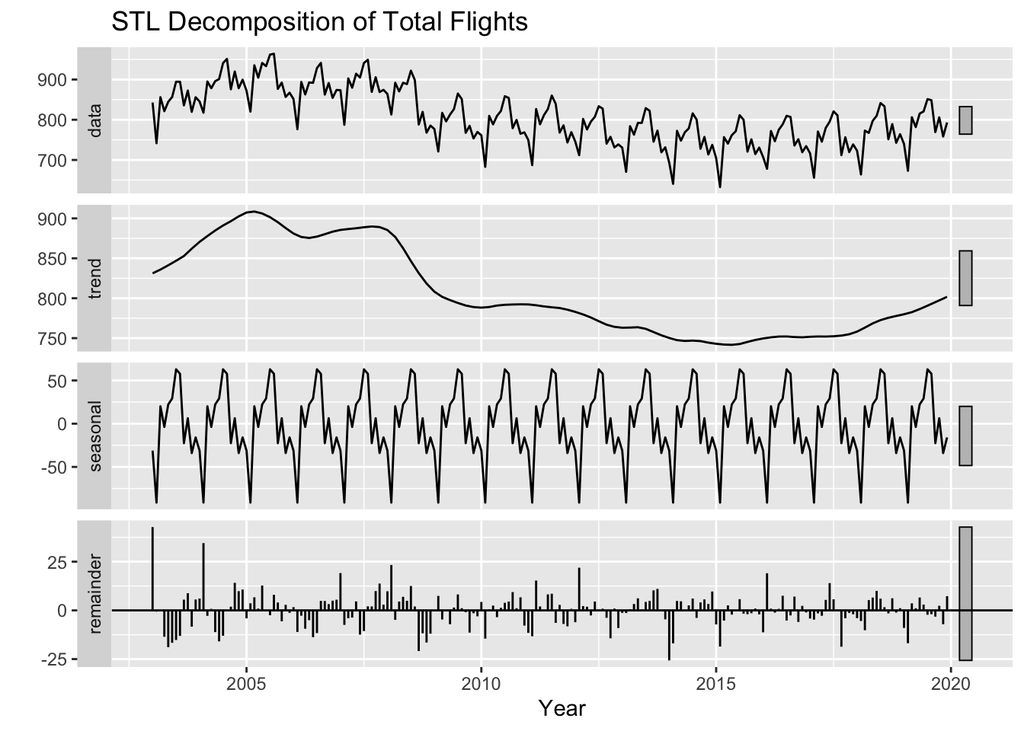

```r
stl_decomposed <- stl(air_ts, s.window = "periodic")

autoplot(stl_decomposed) +
  labs(title = "STL Decomposition of Total Flights", x = "Year")
```

The original time series represents the observed data, combining trend, seasonality, and residual noise. The data exhibits non-stationarity, as evidenced by the downward trend and seasonal fluctuations. Non-stationarity implies that the mean and variance of the series change over time. The variability in the data appears consistent over time, with no significant changes in the amplitude of fluctuations.

#### Remainder Component

- The remainder component represents random noise or unexplained variability after removing trend and seasonality.
- Residuals fluctuate around zero with no discernible pattern, suggesting that most of the systematic variation has been accounted for by the trend and seasonal components.
- There are occasional spikes, which could indicate outliers or events not captured by the model (e.g., unexpected shocks or anomalies).
- In general, the residuals are well-behaved (centered around zero), suggesting that the decomposition effectively captures most of the systematic variation in the data.

#### Seasonal Component

- The periodicity is consistent across years, with peaks and troughs repeating at regular intervals. This indicates strong additive seasonality (as opposed to multiplicative seasonality, which would show increasing amplitude over time).
- The seasonal variation accounts for approximately 5% – 8% of the total traffic volume relative to the baseline. The amplitude of seasonal fluctuations appears consistent over time (no visible increase or decrease in peaks and troughs).

**Seasonal Subseries**

A seasonal subseries plot is a valuable tool to explore the seasonal variation in time series data. It aids in understanding how each month’s data behaves over several years, thereby highlighting within-year seasonality.

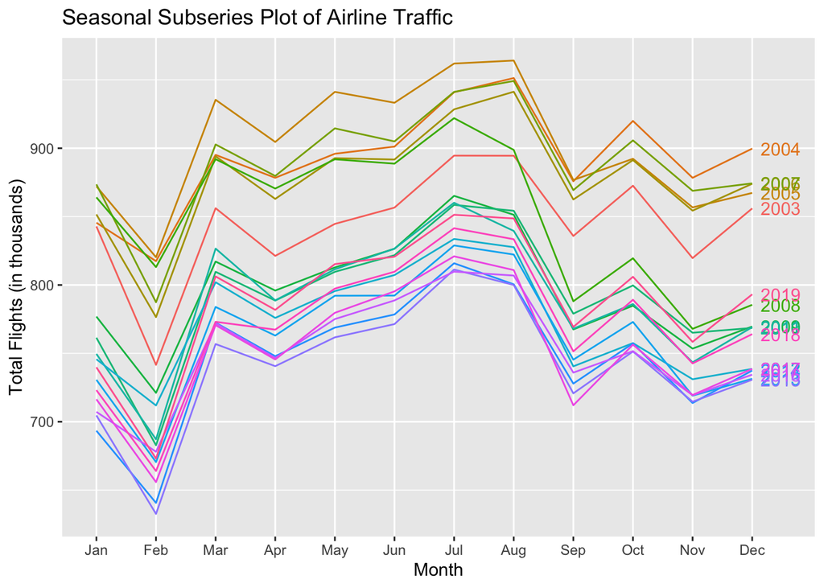

```r
ggseasonplot(air_ts,
           year.labels = TRUE,
           main = "Seasonal Subseries Plot of Airline Traffic",
           ylab = "Total Flights (in thousands)",
           xlab = "Month")
```

We can further confirm the additive seasonality in the data with a log transformation test. If the seasonal pattern becomes constant after applying the log transformation, it suggests multiplicative seasonality (3). If no change is observed, it confirms additive seasonality.

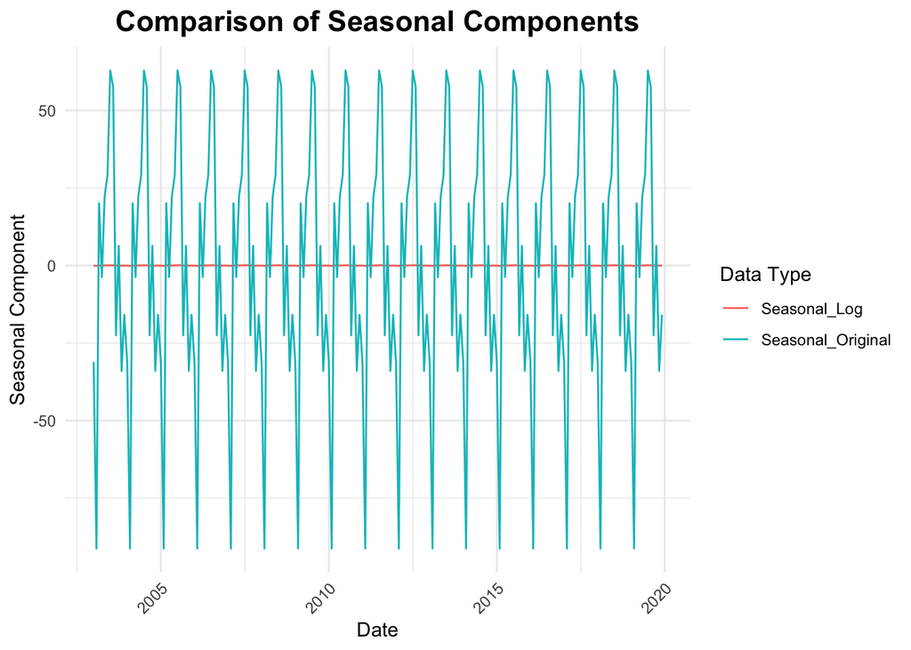

```r
stl_original <- stl(air_ts, s.window = "periodic")
seasonal_original <- stl_original$time.series[, "seasonal"]

log_ts_flt <- log(air_ts)
stl_log <- stl(log_ts_flt, s.window = "periodic")
seasonal_log <- stl_log$time.series[, "seasonal"]

date_sequence <- seq.Date(from = as.Date("2003-01-01"), by = "month", length.out = length(seasonal_original))

seasonal_df <- data.frame(
  Date = date_sequence,
  Seasonal_Original = seasonal_original,
  Seasonal_Log = seasonal_log
) %>%
  pivot_longer(cols = c("Seasonal_Original", "Seasonal_Log"), names_to = "Type", values_to = "Seasonal")

ggplot(seasonal_df, aes(x = Date, y = Seasonal, color = Type)) +
  geom_line() +
  labs(
    title = "Comparison of Seasonal Components",
    x = "Date",
    y = "Seasonal Component",
    color = "Data Type"
  ) +
  theme_minimal() +
  theme(
    plot.title = element_text(size = 16, face = "bold", hjust = 0.5),
    axis.text.x = element_text(angle = 45, hjust = 1)
  )
```

### Detrending

Many spectral analysis methods assume the data is stationary, so removing trends is crucial to meet this assumption (4). Sometimes trends can obscure the underlying cyclical patterns and frequencies we are trying to identify in the spectrum.

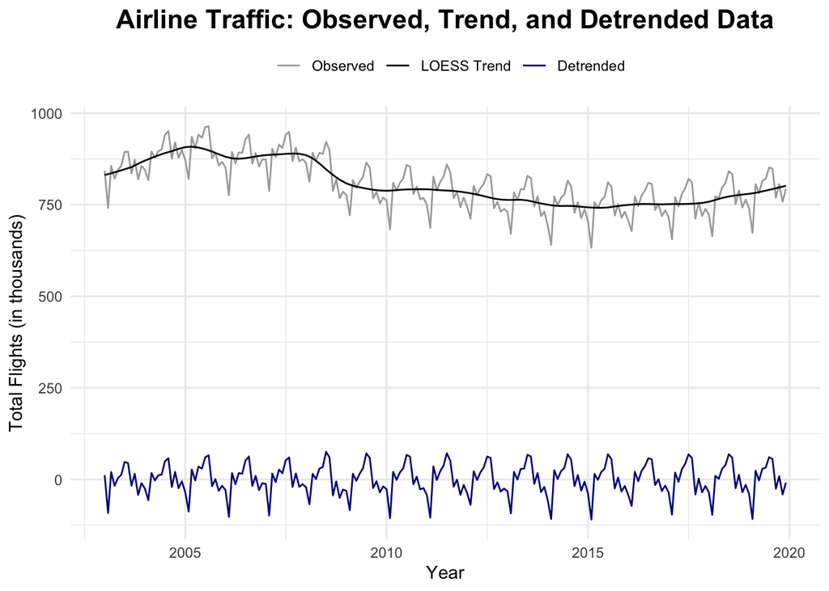

```r
stl_decomposed <- stl(air_ts, s.window = "periodic")

trend <- stl_decomposed$time.series[, "trend"]
detrended_data <- air_ts - trend

df <- data.frame(
  Date = as.Date(as.yearmon(time(air_ts))),
  Observed = as.numeric(air_ts),
  Trend = as.numeric(trend),
  Detrended = as.numeric(detrended_data)
)

ggplot(df, aes(x = Date)) +
  geom_line(aes(y = Observed, colour = "Observed")) +
  geom_line(aes(y = Trend, colour = "LOESS Trend")) +
  geom_line(aes(y = Detrended, colour = "Detrended")) +
  scale_colour_manual(
    "",
    breaks = c("Observed", "LOESS Trend", "Detrended"),
    values = c("darkgray", "black", "darkblue")
  ) +
  labs(
    x = "Year",
    y = "Total Flights (in thousands)",
    title = "Airline Traffic: Observed, Trend, and Detrended Data"
  ) +
  theme_minimal() +
  theme(
    plot.title = element_text(size = 16, face = "bold", hjust = 0.5),
    legend.position = "top"
  )
```

We can see in the above plot that the observed data fluctuates while the LOESS trend reveals an initial increase followed by a decrease and slight recovery, and the detrended data highlights a consistent seasonal pattern after removing the overall trend and appears stationary.

### Spectral Analysis

Spectral analysis is a method used to examine the frequency domain characteristics of a time series. Instead of analyzing the data in the domain (where we observe values over time), spectral analysis decomposes the signal into its contituent frequencies, helping to identify periodic patterns.

A time series $X_t$ can be expressed in terms of its frequency components using the Discrete Fourier Transform (DFT) (5),
$$X(f) = \sum_{t=0}^{N-1} X_te^{-i2\pi ft}$$
where,

- $X_t$ is the observed time series,
- $N$ is the total number of observations,
- $f$ is the frequency (measured in cycles per unit time),
- $i = \sqrt-1$ is the imaginary unit

The power at each frequency is obtained by computing the periodogram, which estimates the power spectral density (PSD) of the signal. The periodogram is defined as [6],

$$I(f) = I(f) = \frac{1}{N} \left| X(f)
\right|^2 = \frac{1}{N} \left| \sum_{t=0}^{N-1} X_t e^{-i 2\pi f t}
\right|^2$$

where $I(f)$ represents the estimated spectral density at frequency $f$. If $I(f)$ has a peak at specific frequency $f_0$, this suggests a strong periodic component in the data with period $T = \frac{1}{f_0}$. Since the raw periodogram is noisy, smoothing is used to obtain a better estimate of the true spectral density function $S(f)$:
$$\hat{S}(f) = \sum_{j=-M}^{M} W(j) I(f_j)$$
where $W(j)$ is a weighting function that smooths the periodogram over nearby frequencies.

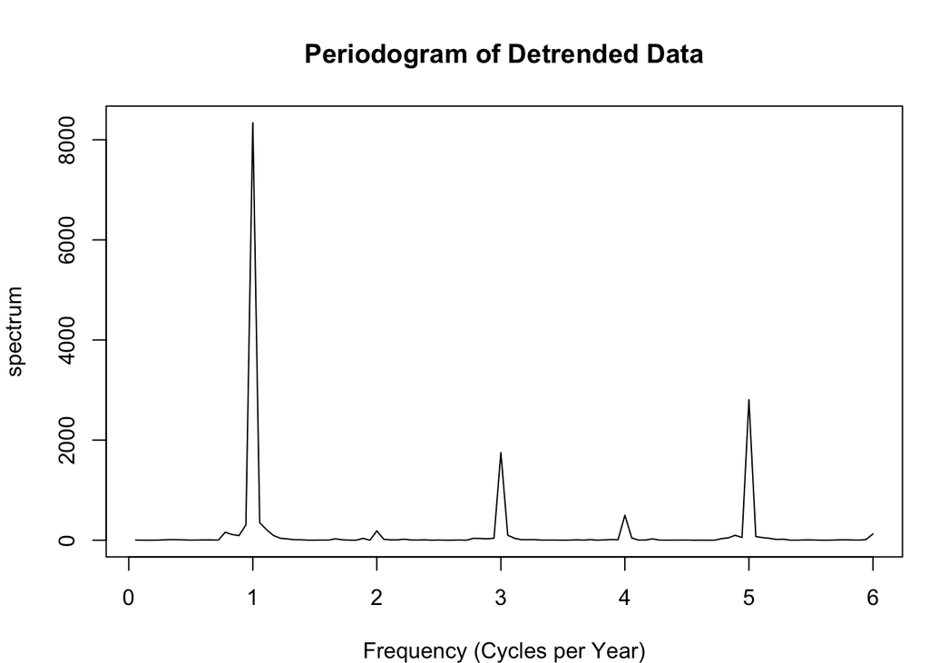

```r
# Compute and plot the periodogram
par(mfrow = c(1,1), mar = c(4, 4, 4, 1))
spectrum(detrended_data, log = "no", main = "Periodogram of Detrended Data", xlab = "Frequency (Cycles per Year)")
```

- The above plot shows the spectral density of the detrended time series data across different frequencies.
- The highest peak at a frequency near 1 suggests a strong periodic component in the data. Other smaller peaks at higher frequencies indicate additional periodic signals, but they are weaker compared to the dominant one.

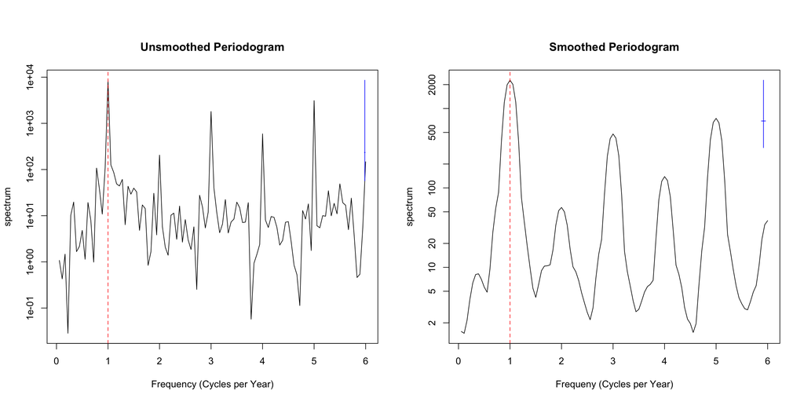

```r
# Set up the plotting area to display two plots side-by-side
par(mfrow = c(1, 2), oma = c(0, 0, 2, 0))

# Unsmoothed Periodogram
unsmoothed_pg <- spectrum(detrended_data,
                          spans = NULL,  # No smoothing window (unspecified)
                          taper = 0,     # No taper
                          xlab = "Frequency (Cycles per Year)",
                          sub = "",
                          main = "Unsmoothed Periodogram")

# Identify and mark the dominant frequency for the unsmoothed periodogram
dominant_freq_unsmoothed <- unsmoothed_pg$freq[which.max(unsmoothed_pg$spec)]
abline(v = dominant_freq_unsmoothed, lty = 2, col = "red")

# Smoothed Periodogram
smoothed_pg <- spectrum(detrended_data,
                        spans = c(3, 5), # Simple example of a smoothing window
                        taper = 0.1,    # Apply a taper to reduce leakage
                        xlab = "Frequeny (Cycles per Year)",
                        sub = "",
                        main = "Smoothed Periodogram")

# Identify and mark the dominant frequency for the smoothed periodogram
dominant_freq_smoothed <- smoothed_pg$freq[which.max(smoothed_pg$spec)]
abline(v = dominant_freq_smoothed, lty = 2, col = "red")
```

```r
# # Output dominant frequencies and corresponding periods
# cat("Unsmoothed dominant frequency (cycles per month): ", dominant_freq_unsmoothed, "\n")
# cat("Unsmoothed corresponding period (months): ", 1/dominant_freq_unsmoothed, "\n")
#
# cat("Smoothed dominant frequency (cycles per month): ", dominant_freq_smoothed, "\n")
# cat("Smoothed corresponding period (months): ", 1/dominant_freq_smoothed, "\n")
```

- The unsmoothed periodogram appears nosiy, with many fluctuations in spectral density. The highest peak (marked by the red dashed line) suggests the dominant frequency in the data.
- The smoothed periodogram provides a clearer view of the dominant frequency components. The smoothing reduces noise and highlights significant periodicities.
- The large peak at frequency ~1 cycle per year confirms a strong annual seasonality in the data, while additional peaks at frequencies around 3 and 5 suggest secondary periodic components.

## Model Selection

The following model selection process follows these steps:

1. ARIMA Model Selection
- Compare ARIMA(p,1,q) models for $p,q=1,2$ based on AIC values
- Conduct the Box-Ljung test to assess residual independence
2. SARIMA Model Selection
- Compare SARIMA models with different seasonal parameters to determine the optimal model
3. Model Diagnostics
- Check residuals for:
  - Constant mean & variance(homoscedasticity).
  - Independence (autocorrelation check).
  - Normality (e.g., Q-Q plot, Shapiro-Wilk test).

#### ARIMA Model Selection

Because the time series data was found to have evidence of non-stationarity, we will consider Integrated Autoregressive Moving Average (ARIMA) models which introduce the difference operator $(1 - B)^d$ to model non-stationary time series data effectively (1).

The ARIMA(p,d,q) model includes three components:

- AR (Autoregressive) component: Captures dependencies between past observations and the current value.
- I (Integrated): The differencing part, which removes trends or seasonality (with order $d$).
- MA (Moving Average) component: Models the relationship between past forecast errors and current values.

where

- $p$ is the number of AR terms
- $q$ is the number of MA terms
- $d$ is the order of difference (in this case, we use d=1)

Mathematically, the ARMA(p, 1, q) model can be expressed as:

$$\phi(B)((1-B)Y_n - \mu) = \psi(B)\epsilon_n$$

where:

- $\epsilon_n \sim N(0,\,\sigma^{2})$
- $B$ is the backshift operator
- $\mu = E[Y_n]$
- $\phi(x) = 1 - \phi_1 x - \cdots - \phi_p x^p$
- $\psi(x) = 1 + \psi_1 x + \cdots + \psi_q x^q$

Model selection for ARIMA(p,1,q) models involves choosing appropriate values for the $(p,q)$ parameters. This is typically done by comparing models based on their Akaike Information Criterion (AIC) values (2).

```r
# Compare AIC for AR(0-2) and MA(0-2)
# ARMA model selection code

# Compare AIC for AR(0-2) and MA(0-2)
arma_models <- list()
aic_values <- matrix(NA, nrow=3, ncol=3, dimnames=list(paste0("AR",0:2), paste0("MA",0:2)))
for (p in 0:2) {
  for (q in 0:2) {
    arma_models[[paste(p,q,sep="-")]] <- arima(air_ts, order=c(p,1,q))
    aic_values[p+1, q+1] <- arma_models[[paste(p,q,sep="-")]]$aic
  }
}
print(aic_values)
```

```
##          MA0      MA1      MA2
## AR0 2161.396 2120.142 2114.950
## AR1 2116.663 2117.739 2110.854
## AR2 2117.403 2097.033 2081.034
```

```r
# Select best ARMA model based on AIC
best_arma <- which(aic_values == min(aic_values), arr.ind = TRUE)
best_arma_model <- arima(air_ts, order=c(best_arma[1]-1, 0, best_arma[2]-1))
```

By AIC, the selected model is ARIMA(2,1,2). Before continuing, we will consider the possibility that this low AIC is a result of overfitting and use the LRT to determine if there is a significant benefit in adding one more parameter ($p$ or $q$).

1. ARIMA(1,1,2) vs. the selected model ARIMA(2,1,2)

```
## LRT Statistic: 31.81949
##  P-value: 1.691867e-08
```

2. ARIMA(2,1,1) vs. the selected model ARIMA(2,1,2)

```
## LRT Statistic: 17.99881
##  P-value: 2.210425e-05
```

At the $\alpha = 0.05$ level, we reject the null hypothesis that either the ARIMA(1,1,2) and ARIMA(2,1,1) model are sufficient and will continue on with the ARIMA(2,1,2) model selected by the AIC.

### Box-Ljung Test

(2). The Box-Ljung test is a statistical test used to determine whether there is significant autocorrelation in the residuals of a time series model. It helps assess whether a model has captured all meaningful information in the data.

- A high p-value ($p > 0.05$) suggests that the residuals are independent, meaning the model adequately fits the data.
- A low p-value ($p < 0.05$) indicates that significant autocorrelation remains, suggesting that the model may need improvement.
- The Box-Ljung test is commonly used after fitting ARMA or SARIMA models to validate their effectiveness.
- If the test fails to reject the null hypothesis ($H_0$), it implies that there is no significant autocorrelation in the residuals, confirming a good model fit.

```r
box_test_arma <- Box.test(residuals(best_arma_model), type="Ljung-Box")
print(box_test_arma)
```

```
##
##  Box-Ljung test
##
## data:  residuals(best_arma_model)
## X-squared = 2.4533, df = 1, p-value = 0.1173
```

```r
# Function to plot AR and MA unit roots
plot_unit_roots <- function(model) {
  roots_ar <- polyroot(c(1, -model$coef[grep("ar", names(model$coef))]))
  roots_ma <- polyroot(c(1, model$coef[grep("ma", names(model$coef))]))

  par(mfrow=c(1,2))
  plot(roots_ar, xlim=c(-1.5, 1.5), ylim=c(-1.5, 1.5), main="Inverse AR roots", xlab="Real", ylab="Imaginary")
  abline(h=0, v=0, col="gray", lty=2)
  symbols(0, 0, circles=1, inches=FALSE, add=TRUE, lwd=2)

  plot(roots_ma, xlim=c(-1.5, 1.5), ylim=c(-1.5, 1.5), main="Inverse MA roots", xlab="Real", ylab="Imaginary")
  abline(h=0, v=0, col="gray", lty=2)
  symbols(0, 0, circles=1, inches=FALSE, add=TRUE, lwd=2)

  par(mfrow=c(1,1))
}
```

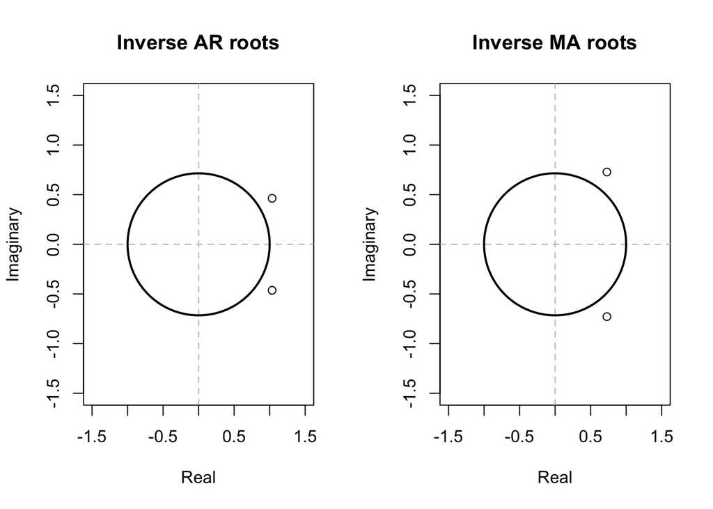

```r
plot_unit_roots(best_arma_model)
```